# Clases y Objetos

## Clase

Una clase en Python es un prototipo o "blueprint" para crear objetos. Las clases encapsulan datos para el objeto y métodos para manipular estos datos. Una clase es una definición abstracta de un objeto.

Características de las clases en Python:

- **Atributos de clase**: Son variables que se definen dentro de la clase y fuera de cualquier método. Estos atributos son comunes para todos los objetos de la clase y se acceden usando el nombre de la clase.
- **Métodos**: Son funciones definidas dentro de una clase que operan sobre los datos miembro de la clase y sirven para manipularlos. Los métodos tienen un parámetro especial llamado self, que se refiere a la instancia del objeto que invoca el método.
- **Constructor (__init__)**: Es un método especial que se invoca automáticamente cuando se crea un objeto de una clase. Se usa para inicializar los atributos del objeto.
- **Herencia**: Es un mecanismo que permite a una clase heredar atributos y métodos de otra clase. La clase que hereda se llama subclase, y la clase de la cual se hereda se llama superclase.
- **Encapsulamiento**: Es la ocultación de los detalles de implementación y se logra mediante el uso de modificadores de acceso (public, private, y protected en otros lenguajes, aunque en Python se utiliza un guion bajo como convención para indicar que un atributo o método es "protegido").
- **Polimorfismo**: Es la habilidad de usar una interfaz común para diferentes tipos de datos. En Python, el polimorfismo es intrínseco debido a su tipado dinámico.

## Objeto

Un objeto es una instancia de una clase. Es la realización concreta de una clase y funciona como una variable de esa clase. Cada objeto tiene una identidad, un tipo y un valor.

Características de los objetos en Python:

- **Atributos de objeto**: También conocidos como campos o propiedades. Estos son datos que pertenecen al objeto. Cada objeto puede tener valores diferentes para sus atributos.
- **Métodos**: Son funciones que operan sobre los atributos de objeto. Un método puede modificar el estado de un objeto o realizar operaciones utilizando el valor de los atributos del objeto.
- **Identidad**: Es una etiqueta única e inmutable asociada con el objeto. Se puede pensar en esto como la dirección de memoria del objeto, y en Python, puede accederse utilizando la función id().
- **Referencias**: Una variable en Python que se utiliza para almacenar un objeto, en realidad, almacena una referencia o puntero al objeto, no el objeto en sí.
- **Ciclo de vida**: Los objetos se crean, se utilizan y eventualmente se destruyen. Python tiene un recolector de basura que se encarga de destruir los objetos que ya no están en uso.

### Ejemplo 1

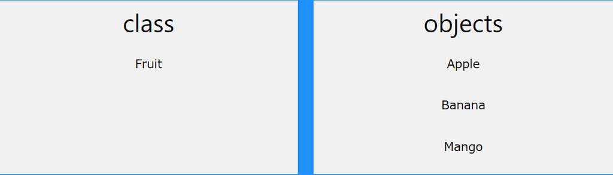

### Ejemplo 2

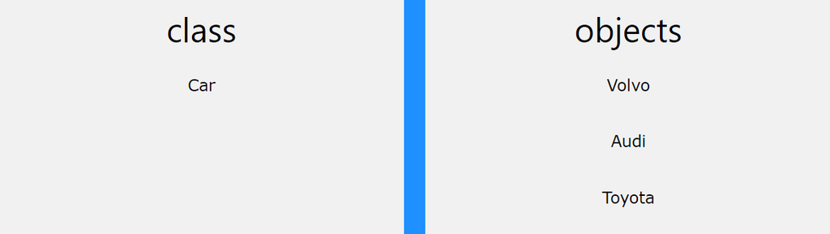

## Clase: Definición y características de la clase

```python
class Coche:
    # Atributo de clase
    numero_de_ruedas = 4

    # Constructor
    def __init__(self, marca, modelo):
        # Atributos del objeto (también conocidos como atributos de instancia)
        self.marca = marca
        self.modelo = modelo

    # Método
    def mostrar_informacion(self):
        return f"El coche es un {self.marca} {self.modelo}"
```

### Explicación:

- La clase se llama **Coche**.
- **numero_de_ruedas** es un atributo de clase que es común para todos los coches.
- El método **__init__** es el constructor y se utiliza para inicializar los atributos de instancia: **marca** y **modelo**.
- **mostrar_informacion** es un método que retorna una cadena con información sobre el coche.

## Objeto: Creación y uso del objeto

```python
# Creación de un objeto de la clase Coche
mi_coche = Coche("Toyota", "Corolla")

# Acceder a los atributos del objeto
print(mi_coche.marca)  # Salida: Toyota
print(mi_coche.modelo) # Salida: Corolla
```

```
Toyota
Corolla
```

- **mi_coche** es una instancia (o objeto) de la clase **Coche**.
- Accedemos a los atributos del objeto usando **mi_coche.marca** y **mi_coche.modelo**.

```python
# Acceder a un atributo de clase
print(Coche.numero_de_ruedas)  # Salida: 4
print(mi_coche.numero_de_ruedas)  # También salida: 4
```

```
4
4
```

- A pesar de que **numero_de_ruedas** es un atributo de clase, aún podemos acceder a él a través de un objeto o directamente a través de la clase.

```python
# Usar un método del objeto
print(mi_coche.mostrar_informacion())  # Salida: El coche es un Toyota Corolla

# Identidad del objeto
print(id(mi_coche))  # Mostrará un número único que representa la identidad de mi_coche

# Referencias
otra_referencia = mi_coche
print(id(otra_referencia))  # Mostrará el mismo número que id(mi_coche), ya que ambos apuntan al mismo objeto
```

```
El coche es un Toyota Corolla
135540978962336
135540978962336
```

- **mostrar_informacion** es un método del objeto que podemos invocar.
- La función *id()* nos da la identidad del objeto, que es esencialmente su dirección en memoria.
- Al asignar mi_coche a otra_referencia, ambos nombres ahora hacen referencia al mismo objeto en memoria.

## **Constructor**

El constructor es un método especial que se utiliza en las clases de programación orientada a objetos para inicializar los atributos de un nuevo objeto. En Python, el constructor se denota por **__init__**.

Características del constructor en Python:

- Nombre Especial: En Python, el constructor tiene el nombre especial **__init__**.
- Automáticamente Invocado: Se invoca automáticamente al crear un nuevo objeto a partir de una clase. No es necesario llamarlo explícitamente.
- Parámetro '**self**': Siempre tiene al menos un argumento: **self**, que es una referencia automática al objeto que se está creando. Puede tener más argumentos si es necesario para inicializar el objeto.
- Inicialización de Atributos: Se utiliza principalmente para establecer los valores iniciales de los atributos de instancia del objeto.

```python
class Libro:
    def __init__(self, titulo, autor, paginas):
        # Atributos de instancia
        self.titulo = titulo
        self.autor = autor
        self.paginas = paginas

# Creación de un objeto de la clase Libro
mi_libro = Libro("1984", "George Orwell", 328)

# Acceder a los atributos del objeto
print(mi_libro.titulo)  # Salida: 1984
print(mi_libro.autor)   # Salida: George Orwell
print(mi_libro.paginas) # Salida: 328
```

```
1984
George Orwell
328
```

# Ejemplo

1. **Cuenta Bancaria**

Objetivo: Representar una cuenta bancaria con un saldo inicial de cero. La cuenta permite realizar depósitos y retiros. Al intentar retirar una cantidad mayor a la disponible en el saldo, el sistema notificará que no es posible debido a fondos insuficientes.

### *Paso a paso*

1. Definición de la Clase y Constructor:
- Se necesita una clase llamada **CuentaBancaria**.
- Esta clase debe iniciar con un saldo de cero. Para ello, se usará el constructor `__init__` y se establecerá el **atributo** **saldo** a 0.
2. Métodos para Operaciones Bancarias:
3. **Depósito**: * Se necesita un método llamado **depositar** * Este método tomará un parámetro, **monto**, que representa la cantidad a depositar * El saldo actual debe incrementarse por este monto
4. **Retiro** * Se necesita otro método llamado **retirar** * Este método también tomará un parámetro, **monto**, que representa la cantidad a retirar. * Antes de realizar el retiro, se debe verificar si el saldo actual es suficiente para cubrir el monto del retiro. * Si no hay suficientes fondos, se debe imprimir un mensaje "Fondos insuficientes" y no realizar el retiro. * Si hay suficientes fondos, se deducirá el **monto** del saldo actual.
5. **Creación y Manipulación de un Objeto de la Clase:**
- Después de definir la clase, puedes crear una instancia (objeto) de **CuentaBancaria**.
- Utilizando esta instancia, puedes depositar un monto, por ejemplo, 100.
- Luego, puedes intentar retirar montos del saldo, por ejemplo, 40 y luego 70.

```python
class CuentaBancaria:
    def __init__(self):
        self.saldo = 0

    def depositar(self, monto):
        """Agrega el monto especificado al saldo actual."""
        self.saldo += monto
        return self.saldo

    def retirar(self, monto):
        """Intenta retirar el monto especificado. Si no hay fondos suficientes,
        muestra un mensaje de error. En caso contrario, descuenta el monto del saldo."""
        if monto <= self.saldo:
            self.saldo -= monto
        else:
            print("Fondos insuficientes")
        return self.saldo

cuenta = CuentaBancaria()
```

#### Deposítemos 100 unidades

```python
print(cuenta.depositar(100))  # Salida: 100
```

```
100
```

#### Retiremos 40 unidades

```python
print(cuenta.retirar(40))    # Salida: 60
```

```
60
```

#### Retiremos 70 unidades

```python
print(cuenta.retirar(70))    # Salida: "Fondos insuficientes" y luego 60
```

```
Fondos insuficientes
60
```

## Ejercicios

1. Biblioteca

**Enunciado**: Diseña una clase Libro que represente un libro con título, autor y número de páginas. Además, crea una clase Biblioteca que almacene múltiples libros y permita agregar y buscar libros por título y autor.

```python
# Pasos
# 1) Definir la clase Libro
class Libro:
    def __init__(self, titulo, autor, num_paginas):
        self.titulo = titulo
        self.autor = autor
        self.num_paginas = num_paginas

    def __str__(self):
        return f"'{self.titulo}' por {self.autor}, {self.num_paginas} páginas"
```

```python
# Definir la clase Biblioteca
class Biblioteca:
    def __init__(self):
        self.libros = []

    def agregar_libro(self, libro):
        if not isinstance(libro, Libro):
            print("El objeto no es un libro válido.")
            return
        self.libros.append(libro)

    def buscar_por_titulo(self, titulo):
        resultado = [str(libro) for libro in self.libros if libro.titulo == titulo]
        return resultado

    def buscar_por_autor(self, autor):
        resultado = [str(libro) for libro in self.libros if libro.autor == autor]
        return resultado

    def mostrar_libros(self):
        for libro in self.libros:
            print(libro)
```

```python
# Uso
# Crear algunos libros
libro1 = Libro("Don Quijote de la Mancha", "Miguel de Cervantes", 1023)
libro2 = Libro("Cien años de soledad", "Gabriel García Márquez", 417)
libro3 = Libro("La sombra del viento", "Carlos Ruiz Zafón", 544)

# Crear una biblioteca y agregar los libros
biblioteca = Biblioteca()
biblioteca.agregar_libro(libro1)
biblioteca.agregar_libro(libro2)
biblioteca.agregar_libro(libro3)

# Mostrar los libros
biblioteca.mostrar_libros()

# Buscar libros por autor y título
print("\nLibros de Miguel de Cervantes:")
print(biblioteca.buscar_por_autor("Miguel de Cervantes"))

print("\nLibros titulados 'Cien años de soledad':")
print(biblioteca.buscar_por_titulo("Cien años de soledad"))
```

```
'Don Quijote de la Mancha' por Miguel de Cervantes, 1023 páginas
'Cien años de soledad' por Gabriel García Márquez, 417 páginas
'La sombra del viento' por Carlos Ruiz Zafón, 544 páginas

Libros de Miguel de Cervantes:
["'Don Quijote de la Mancha' por Miguel de Cervantes, 1023 páginas"]

Libros titulados 'Cien años de soledad':
["'Cien años de soledad' por Gabriel García Márquez, 417 páginas"]
```

2. Estudiantes y Cursos

**Enunciado**: Diseña una clase Estudiante que tenga un nombre, apellido y una lista de cursos en los que está inscrito. Además, crea una clase Curso que tenga un nombre, una descripción y una lista de estudiantes inscritos. Ambas clases deben permitir agregar y eliminar elementos de sus listas respectivas (cursos para estudiantes, estudiantes para cursos).

3. Tienda de Electrodomésticos

**Enunciado**: Diseña una clase Electrodomestico que represente un artículo con nombre, precio y garantía (en meses). Luego, crea una clase Tienda que contenga un inventario de electrodomésticos y permita agregar nuevos productos, buscar productos por nombre y vender (eliminar) productos.

4. Aerolínea

**Enunciado**: Diseña una clase Pasajero que represente a una persona con nombre, apellido y número de pasaporte. Luego, crea una clase Vuelo que contenga detalles del vuelo como número de vuelo, destino y una lista de pasajeros. El vuelo debe permitir el embarque y desembarque de pasajeros.

## Investigar "dunder methods"!!!